# Predict salary of programmers in China by supervised learning

DSC5103 Final Report

G2Group09: Huang Zijian(A0176583R), Li Jiazhe(A0176576M), Wang Jia(A0176605B), Vignesh Palraj(A0176601J)

Nov 2017

## 1. Problem Definition

### a. Problem Statement

Currently, programmer is one of the highest-paid job in China. We are curious about how their salary are distributed, higher salaries are determined by which type of attributes, for instance, personal qualifications like education and skills, company and job attributes like company scale and location. Also, we try to make a prediction on the salary of different programmers in China. Several supervised learning models are adopted to solve this regression problem.

Main targets of our project are as follows:

1. Identifying individual qualifications as well as company attributes’ effect on programmer’s salary in China.
2. Making robust prediction on individual salary based on machine learning algorithms.
3. Comparing model performances

### b. Data Collection and Processing

#### Data Collection

Our key dataset is from a shared dataset of programmers’ recruitment information data which were crawled from www.jobui.com (a Chinese recruitment webseite. 10949 lines of recruitment data were in the raw data set. Search number(hits) of the company name on Baidu were crawled by us to represent company reputation.

Data source:

```r
rawdata <- read.csv("raw_data.csv")
summary(rawdata)
```

```
##        ID        required.language        position.name          work.experience          education
##  Min.   :    1   C#    : 704       Java          :1314   1-3year         :3940   Bachelor      :6394
##  1st Qu.: 2738   C++   :2018       PHP           :1033   3-5year         :4859   junior college:3452
##  Median : 5475   Java  :4255       C++           : 689   5-10year        : 984   master        :  55
##  Mean   : 5475   PHP   :3025       Java开发工程师: 592   freshgraduate   : 170   Unlimited     :1048
##  3rd Qu.: 8212   Python: 947       PHP开发工程师 : 549   less than 1 year:  60
##  Max.   :10949                     Python        : 277   over 10 years   :   7
##                                    (Other)       :6495   unlimited       : 929
##  salary_lower_bound salary_upper_bound    company.scale       location                            series.level
##  Min.   : 1.00      Min.   : 2.00      15-50人   :2382   Beijing  :1913   startup (no financing)        :2008
##  1st Qu.: 8.00      1st Qu.:12.00      150-500人 :2347   Shenzhen :1501   listed company                :1789
##  Median :10.00      Median :16.00      2000人以上:1613   Shanghai :1443   developing (no financing need):1443
##  Mean   :10.67      Mean   :18.27      50-150人  :2698   Guangzhou:1317   developing (A round)          :1425
##  3rd Qu.:15.00      3rd Qu.:24.00      500-2000人:1441   Hangzhou :1144   startup (angel round)         : 983
##  Max.   :70.00      Max.   :90.00      少于15人  : 468   Chengdu  : 912   developing (B round)          : 884
##                                                          (Other)  :2719   (Other)                       :2417
##                    company.name     search.num
##  通力互联                :   99   Min.   :        6
##  上海华腾软件系统有限公司:   37   1st Qu.:    60100
##  华为技术有限公司        :   35   Median :   548000
##  武汉佰钧成技术有限公司  :   35   Mean   :  3546162
##  深圳易思博软件          :   32   3rd Qu.:  2270000
##  同花顺                  :   31   Max.   :100000000
##  (Other)                 :10680
```

```r
head(rawdata)
```

```
##   ID required.language                         position.name work.experience education salary_lower_bound
## 1  1               C++                YSBG-PC开发工程师(C++)         1-3year  Bachelor                 10
## 2  2               C++              YSBG-C++开发工程师(游戏)         1-3year Unlimited                 10
## 3  3               PHP              YSBG-后端开发工程师(PHP)         1-3year Unlimited                  8
## 4  4               C++              YSBG-后端开发工程师(C++)       unlimited  Bachelor                 15
## 5  5               C++ WX-高级服务器开发工程师（linuxc/c++）         3-5year  Bachelor                 16
## 6  6               C++                WindowsC/C++研发工程师         3-5year  Bachelor                  8
##   salary_upper_bound company.scale  location               series.level                 company.name search.num
## 1                 20    500-2000人 Guangzhou mature (no financing need)                     酷狗音乐    7900000
## 2                 15    500-2000人 Guangzhou mature (no financing need)                     酷狗音乐    7900000
## 3                 11    500-2000人 Guangzhou mature (no financing need)                     酷狗音乐    7900000
## 4                 25    500-2000人 Guangzhou mature (no financing need)                     酷狗音乐    7900000
## 5                 28    500-2000人  Shenzhen             listed company                         迅雷   26500000
## 6                 15    500-2000人 Guangzhou             listed company 蓝盾信息安全技术股份有限公司     627000
```

#### Data Processing

Salary information on the jobui.com is shown by range. We took the average value of the range as our dependent varaibale ‘salary_avg’. Outliers are removed by plotting boxplot. Column position.name is in text format in Chinese. We want to see how different position affect salary by doing feature engineering. In order to extract key job attributes from position description, we merged similar characters.

```r
library("jiebaR")
```

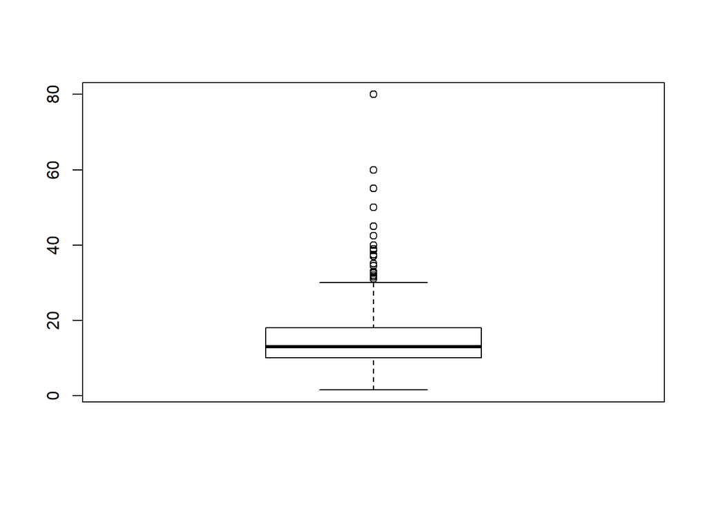

```r
library("wordcloud")
library("stringr")

# calculate average salary as y and remove outliers
rawdata$salary_avg <- as.numeric((rawdata$salary_lower_bound+rawdata$salary_upper_bound)/2)
box <- boxplot(rawdata$salary_avg)
```

```r
rawdata <- subset(rawdata,rawdata$salary_avg < 32.5 & rawdata$salary_avg > 6) # remove outliers
data <- rawdata[,-c(1,6,7)]

# text cleaning
data$position.name <- tolower(as.character(data$position.name))
data$position.name <- str_replace_all(data$position.name, "资深", "高级") # combine similar words
data$position.name <- str_replace_all(data$position.name, "web", "前端")
data$position.name <- str_replace_all(data$position.name, "网站", "前端")
data$position.name <- str_replace_all(data$position.name, "客户端", "前端")
data$position.name <- str_replace_all(data$position.name, "服务端", "后端")
data$position.name <- str_replace_all(data$position.name, "服务器", "后端")
data$company.scale <- str_replace_all(data$company.scale, "人", "")
data$company.scale <- str_replace_all(data$company.scale, "以上", "<")
data$company.scale <- str_replace_all(data$company.scale, "以下", "<")
data$company.scale <- str_replace_all(data$company.scale, "少于", ">")
data$company.scale <- as.factor(data$company.scale)
data <- subset(data, str_detect(data$position.name, "实习")==FALSE) # delete internships
```

Subsequently, we did text mining to get the frequency of key attributes of position descriptions. Attributes with word frequency larger than 20 were picked. Some common words which cannot differentiate programmers’ positon were not picked, such as “engineer” and “software”.

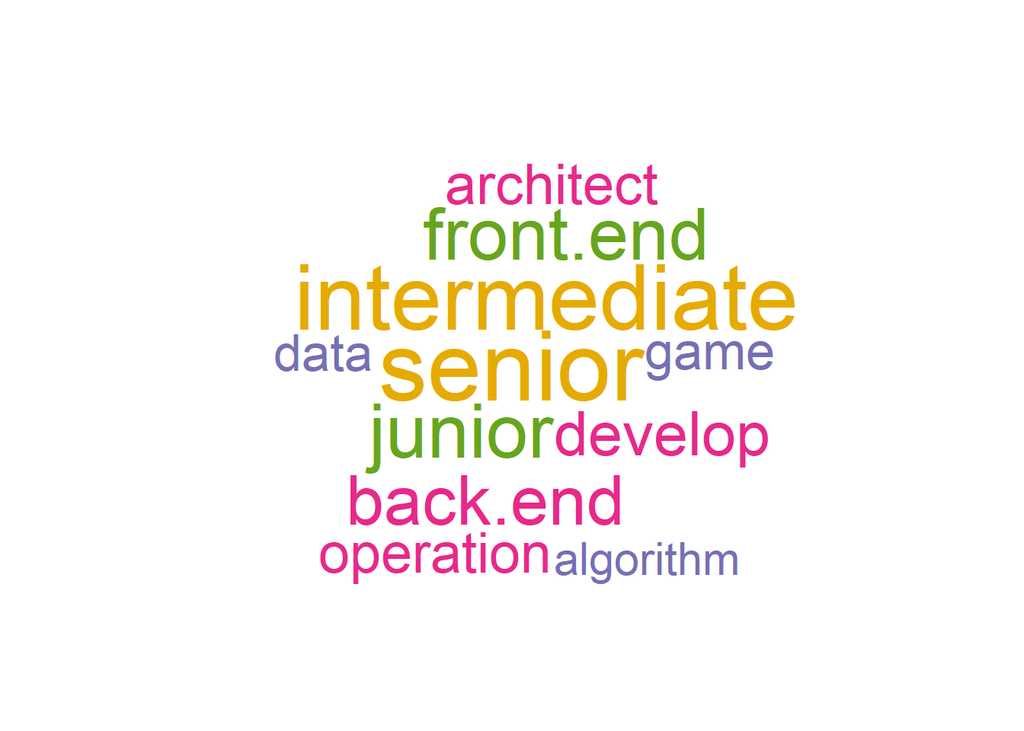

```r
# use package "fenci" to get Chinese words in strings
wk = worker()
position <- wk[data$position.name]
position_freq <- table(position) # word frequency table
seg <- sort(position_freq, decreasing = TRUE)[1:100]

# pick up words we want:
words <- c("高级","中级","初级","前端","后端","开发","架构师","运维","游戏","数据","算法","研发")
position.key <- position[position %in% words]
position.key.freq <- table(position.key) # word frequency table
seg.key <- sort(log(position.key.freq), decreasing = TRUE) # take log so as to make the graph pretty

# wordcloud
colors=brewer.pal(6,"Dark2")
set.seed(123)
words.en <- c("senior", "intermediate", "junior",   "front.end", "back.end", "develop", "architect", "operation",   "game", "data", "algorithm", "R.D")
wordcloud(words.en, seg.key,colors=colors,random.order=F)
```

```r
# add dummies to data
for(j in 1:length(words)){
  for (i in 1:nrow(data)){
    data[i, j+10] <- ifelse(words[j] %in% wk[data$position.name[i]], 1, 0)
  }
  names(data)[j+10] <- words.en[j]
}
```

Conduct numeric variable of work experience:

```r
# change work experience
data$work.experience.lowerb <- ifelse(data$work.experience=="1-3year",1,ifelse(data$work.experience=="3-5year", 3, ifelse(data$work.experience=="5-10year", 5, ifelse(data$work.experience=="less than 1 year"|data$work.experience=="freshgraduate"|data$work.experience=="unlimited", 0, 10))))
data$work.experience.upperb <- ifelse(data$work.experience=="1-3year",3,ifelse(data$work.experience=="3-5year", 5, ifelse(data$work.experience=="5-10year", 10, ifelse(data$work.experience=="less than 1 year"|data$work.experience=="unlimited", 1, ifelse(data$work.experience=="freshgraduate", 0, 20)))))

#delete useless columns
data <- data[,-c(2,8)]
head(data)
```

```
##   required.language work.experience education company.scale  location               series.level search.num salary_avg
## 1               C++         1-3year  Bachelor      500-2000 Guangzhou mature (no financing need)    7900000       15.0
## 2               C++         1-3year Unlimited      500-2000 Guangzhou mature (no financing need)    7900000       12.5
## 3               PHP         1-3year Unlimited      500-2000 Guangzhou mature (no financing need)    7900000        9.5
## 4               C++       unlimited  Bachelor      500-2000 Guangzhou mature (no financing need)    7900000       20.0
## 5               C++         3-5year  Bachelor      500-2000  Shenzhen             listed company   26500000       22.0
## 6               C++         3-5year  Bachelor      500-2000 Guangzhou             listed company     627000       11.5
##   senior intermediate junior front.end back.end develop architect operation game data algorithm R.D
## 1      0            0      0         0        0       1         0         0    0    0         0   0
## 2      0            0      0         0        0       1         0         0    1    0         0   0
## 3      0            0      0         0        1       1         0         0    0    0         0   0
## 4      0            0      0         0        1       1         0         0    0    0         0   0
## 5      1            0      0         0        1       1         0         0    0    0         0   0
## 6      0            0      0         0        0       0         0         0    0    0         0   1
##   work.experience.lowerb work.experience.upperb
## 1                      1                      3
## 2                      1                      3
## 3                      1                      3
## 4                      0                      1
## 5                      3                      5
## 6                      3                      5
```

The cleaned dataset contains 22 columns:

### c. Descriptive Statistics/ Data Analysis

#### Data Analysis

salary distribution in the whole group:

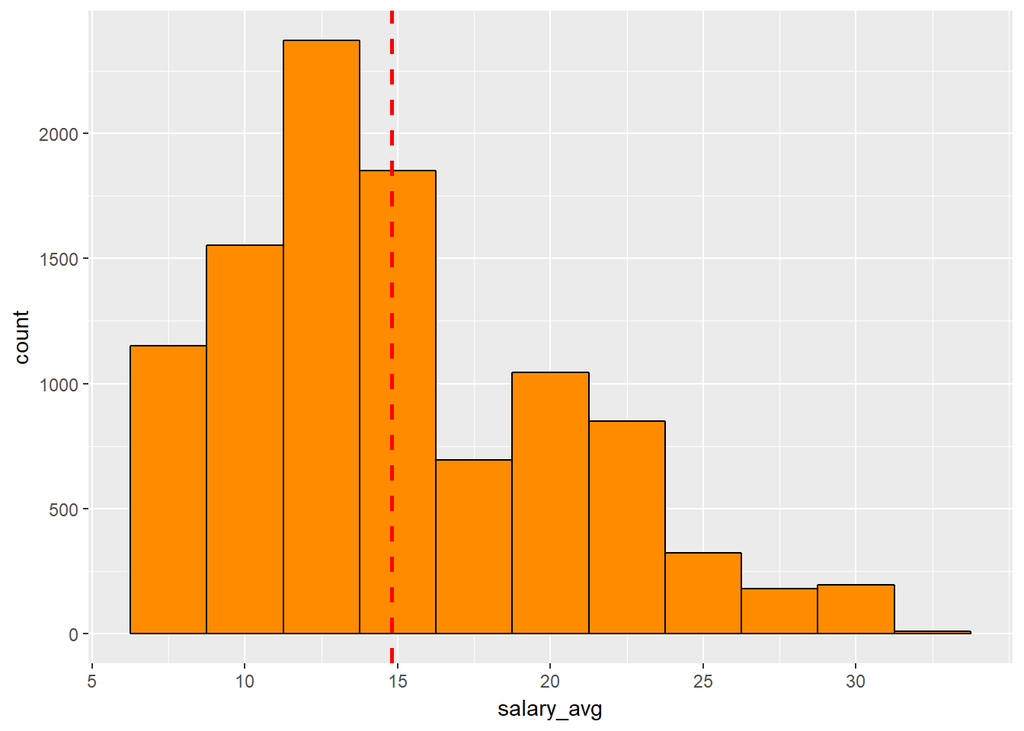

```r
library("ggplot2")
# histogram of salary
ggplot(data, aes(x = salary_avg)) +geom_histogram(binwidth = 2.5, fill = "darkorange", colour = "black") +scale_x_continuous(breaks=seq(0, 30, 5))+geom_vline(aes(xintercept=mean(salary_avg)), color="red", linetype="dashed", size=1)
```

## 2. Analysis Execution

### Methodology

Dependent variable = Salary_avg Predictors = Individual attributes + Company attributes

Build the optimum models using stepAIC, lasso, random forest, xgboost, svm and ensemble for the best test accuracy. These models are chosen for their ability on predicting high dimensional predictors.

Data are spilt to three sets: train data, blender data and test data. We take train data to train single model and predict with blender data and test data. After building single models, we train an ensemble model by combining single models and use blender data as the train data for it. In the end, different models are compared by test data **RMSE**.

### Model Building

spilt full data into 3 sets: train set, blender set and test set:

```r
N <- nrow(data)
set.seed(123)
train.index <- sample(1:N, round(N/2))
datahalf <- data[-train.index,]
M <- nrow(datahalf)
blender.index <- sample(1:M, round(M/2))
test.index <- -blender.index

x.train.m <- model.matrix(salary_avg ~ ., data[train.index, ])[, -1]
y.train <- data[train.index, "salary_avg"]
x.blender.m <- model.matrix(salary_avg ~ ., datahalf[blender.index, ])[, -1]
y.blender <- datahalf[blender.index, "salary_avg"]
x.test.m <- model.matrix(salary_avg ~ ., datahalf[test.index, ])[, -1]
y.test <- datahalf[test.index, "salary_avg"]

x.train <- data[train.index, -8]
x.blender <- datahalf[blender.index, -8]
x.test <- datahalf[test.index, -8]
```

#### Linear model (without regularization)

Since number of predictors is quite high subset selection (2^p) is computationally infeasible. So stepwise is chosen. Since we have a very large dataset, we are using backward as forward works well when p>>n.

```r
library("MASS")
lm.all <- lm(salary_avg ~ .-work.experience.lowerb-work.experience.upperb , data = data, subset = train.index)
lm.mod <- stepAIC(lm.all, direction="backward")
```

```
## Start:  AIC=13354.78
## salary_avg ~ (required.language + work.experience + education +
##     company.scale + location + series.level + search.num + senior +
##     intermediate + junior + front.end + back.end + develop +
##     architect + operation + game + data + algorithm + R.D + work.experience.lowerb +
##     work.experience.upperb) - work.experience.lowerb - work.experience.upperb
##
##                     Df Sum of Sq   RSS   AIC
## - develop            1       0.3 68312 13353
## - front.end          1       7.2 68318 13353
## - game               1      14.4 68326 13354
## - operation          1      18.0 68329 13354
## <none>                           68311 13355
## - junior             1      28.4 68340 13355
## - back.end           1      55.6 68367 13357
## - data               1      92.2 68403 13360
## - algorithm          1     203.9 68515 13368
## - R.D                1     221.2 68532 13369
## - intermediate       1     226.7 68538 13370
## - search.num         1     561.9 68873 13395
## - company.scale      5     811.6 69123 13405
## - architect          1     916.4 69228 13421
## - series.level       9    1339.2 69651 13436
## - education          3    1373.2 69684 13450
## - required.language  4    1456.4 69768 13455
## - senior             1    1958.2 70269 13497
## - work.experience    6   15124.6 83436 14365
## - location          10   27321.2 95632 15055
##
## Step:  AIC=13352.81
## salary_avg ~ required.language + work.experience + education +
##     company.scale + location + series.level + search.num + senior +
##     intermediate + junior + front.end + back.end + architect +
##     operation + game + data + algorithm + R.D
##
##                     Df Sum of Sq   RSS   AIC
## - front.end          1       7.2 68319 13351
## - game               1      14.6 68326 13352
## - operation          1      17.8 68329 13352
## <none>                           68312 13353
```

[output cut: 75 more lines]

```
## - junior             1      29.3 68384 13350
## - back.end           1      85.4 68440 13354
## - data               1      92.5 68447 13355
## - algorithm          1     201.2 68556 13363
## - intermediate       1     226.7 68581 13365
## - R.D                1     226.9 68581 13365
## - search.num         1     559.6 68914 13390
## - company.scale      5     806.7 69161 13400
## - architect          1     917.2 69272 13416
## - series.level       9    1332.4 69687 13431
## - education          3    1365.1 69720 13445
## - required.language  4    1447.9 69802 13449
## - senior             1    1993.4 70348 13495
## - work.experience    6   15151.1 83506 14362
## - location          10   27318.1 95673 15049
```

```r
summary(lm.mod)
```

```
##
## Call:
## lm(formula = salary_avg ~ required.language + work.experience +
##     education + company.scale + location + series.level + search.num +
##     senior + intermediate + junior + back.end + architect + data +
##     algorithm + R.D, data = data, subset = train.index)
##
## Residuals:
##     Min      1Q  Median      3Q     Max
## -11.048  -2.490  -0.347   2.084  15.954
##
## Coefficients:
##                                              Estimate Std. Error t value Pr(>|t|)
## (Intercept)                                 1.420e+01  3.992e-01  35.580  < 2e-16 ***
## required.languageC++                        1.931e+00  2.402e-01   8.040 1.11e-15 ***
## required.languageJava                       1.918e+00  2.288e-01   8.382  < 2e-16 ***
## required.languagePHP                        1.954e+00  2.318e-01   8.430  < 2e-16 ***
## required.languagePython                     2.761e+00  2.756e-01  10.019  < 2e-16 ***
## work.experience3-5year                      3.015e+00  1.233e-01  24.446  < 2e-16 ***
## work.experience5-10year                     6.103e+00  2.122e-01  28.759  < 2e-16 ***
## work.experiencefreshgraduate               -3.535e+00  6.216e-01  -5.687 1.36e-08 ***
## work.experienceless than 1 year            -2.388e+00  8.375e-01  -2.851 0.004378 **
## work.experienceover 10 years                9.147e+00  2.658e+00   3.441 0.000583 ***
## work.experienceunlimited                    7.737e-01  2.188e-01   3.537 0.000409 ***
## educationjunior college                    -1.197e+00  1.202e-01  -9.961  < 2e-16 ***
## educationmaster                             8.646e-01  8.563e-01   1.010 0.312738
## educationUnlimited                         -3.867e-01  1.883e-01  -2.054 0.040071 *
## company.scale15-50                         -2.462e-01  2.912e-01  -0.845 0.397877
## company.scale150-500                        4.093e-01  3.206e-01   1.276 0.201891
## company.scale2000<                          1.683e+00  3.626e-01   4.642 3.54e-06 ***
## company.scale50-150                         5.104e-01  3.082e-01   1.656 0.097790 .
## company.scale500-2000                       1.276e+00  3.541e-01   3.602 0.000318 ***
## locationChangsha                           -7.385e+00  3.040e-01 -24.295  < 2e-16 ***
## locationChengdu                            -6.703e+00  2.264e-01 -29.602  < 2e-16 ***
## locationGuangzhou                          -4.622e+00  2.034e-01 -22.720  < 2e-16 ***
## locationHangzhou                           -2.216e+00  2.081e-01 -10.649  < 2e-16 ***
## locationNanjing                            -5.227e+00  2.540e-01 -20.581  < 2e-16 ***
## locationShanghai                           -1.248e+00  1.905e-01  -6.552 6.24e-11 ***
## locationShenzhen                           -2.334e+00  1.892e-01 -12.338  < 2e-16 ***
## locationSuzhou                             -5.816e+00  3.621e-01 -16.061  < 2e-16 ***
```

[output cut: 11 more lines]

```
## search.num                                  3.521e-08  5.467e-09   6.440 1.31e-10 ***
## senior                                      1.739e+00  1.431e-01  12.154  < 2e-16 ***
## intermediate                               -1.432e+00  3.494e-01  -4.098 4.23e-05 ***
## junior                                     -1.129e+00  7.667e-01  -1.472 0.141002
## back.end                                    7.784e-01  3.095e-01   2.515 0.011923 *
## architect                                   4.216e+00  5.114e-01   8.244  < 2e-16 ***
## data                                        2.260e+00  8.629e-01   2.619 0.008856 **
## algorithm                                   4.519e+00  1.170e+00   3.861 0.000114 ***
## R.D                                         1.093e+00  2.664e-01   4.100 4.19e-05 ***
## ---
## Signif. codes:  0 '***' 0.001 '**' 0.01 '*' 0.05 '.' 0.1 ' ' 1
##
## Residual standard error: 3.674 on 5065 degrees of freedom
## Multiple R-squared:  0.5543, Adjusted R-squared:  0.5502
## F-statistic: 136.9 on 46 and 5065 DF,  p-value: < 2.2e-16
```

Variables eliminated from stepAIC are “game”, “front-end”, “operation”, “develop”, which means that these variables are not important in predicting salary.

```r
# prediction on test data
lm.pred <- predict(lm.mod, datahalf[test.index,-c(8,21,22)])
rmse.lm <- sqrt(mean((lm.pred-y.test)^2))
lm.blender <- predict(lm.mod, x.blender)
```

#### Regularized linear model

```r
# construct model matrix for lasso
library("glmnet")
set.seed(123)
fold <- sample(rep(seq(10), length=nrow(x.train)))

# lasso
lasso.cv <- cv.glmnet(x.train.m, y.train, alpha=1, foldid = fold)
lasso.lam <- lasso.cv$lambda.1se

predict(lasso.cv, type="coefficient", s=lasso.lam, exact=TRUE)
```

```
## 53 x 1 sparse Matrix of class "dgCMatrix"
##                                                        1
## (Intercept)                                 1.323783e+01
## required.languageC++                        7.446269e-01
## required.languageJava                       6.434060e-01
## required.languagePHP                        7.268043e-01
## required.languagePython                     1.756194e+00
## work.experience3-5year                      .
## work.experience5-10year                     .
## work.experiencefreshgraduate               -1.602306e+00
## work.experienceless than 1 year            -2.179697e-01
## work.experienceover 10 years               -1.709754e+00
## work.experienceunlimited                    2.059908e+00
## educationjunior college                    -1.223567e+00
## educationmaster                             7.268071e-02
## educationUnlimited                         -3.265542e-01
## company.scale15-50                         -5.582478e-01
## company.scale150-500                        .
## company.scale2000<                          8.738735e-01
## company.scale50-150                         3.692337e-02
## company.scale500-2000                       5.597109e-01
## locationChangsha                           -6.462434e+00
## locationChengdu                            -5.867142e+00
## locationGuangzhou                          -3.835771e+00
## locationHangzhou                           -1.338078e+00
## locationNanjing                            -4.331498e+00
## locationShanghai                           -4.295768e-01
## locationShenzhen                           -1.540839e+00
## locationSuzhou                             -4.856674e+00
## locationWuhan                              -5.772975e+00
## locationXi'an                              -6.647108e+00
## series.leveldeveloping (B round)            4.370913e-01
## series.leveldeveloping (no financing need) -6.431891e-02
## series.levellisted company                 -3.047281e-01
## series.levelmature (C round)                1.125589e+00
## series.levelmature (D round or over)        .
## series.levelmature (no financing need)     -6.099271e-01
## series.levelstartup (angel round)          -2.976533e-01
## series.levelstartup (no financing need)    -6.490403e-01
## series.levelstartup (no financing)         -9.443199e-01
## search.num                                  3.437515e-08
## senior                                      1.706611e+00
## intermediate                               -1.173230e+00
## junior                                     -5.961492e-01
## front.end                                   .
## back.end                                    4.414146e-01
## develop                                     .
## architect                                   3.761859e+00
## operation                                  -1.826104e-01
## game                                        2.103248e-01
## data                                        1.352825e+00
## algorithm                                   3.681440e+00
## R.D                                         9.951213e-01
## work.experience.lowerb                      1.524387e+00
## work.experience.upperb                      .
```

```r
# predicitions
lasso.pred <- predict(lasso.cv, newx=x.test.m, s=lasso.lam)
rmse.lasso <- sqrt(mean((lasso.pred - y.test)^2))
lasso.blender <- predict(lasso.cv, newx=x.blender.m, s=lasso.lam)
```

```r
# Elastic Net
# candidates for alpha
alphas <- seq(0, 1, 0.05)
# cross-validation to find the best alpha-lambda combination
en.cv.error <- data.frame(alpha=alphas)
for (i in 1:length(alphas)){
  en.cv <- cv.glmnet(x.train.m, y.train, alpha=alphas[i], foldid=fold)
  en.cv.error[i, "lambda.1se"] <- en.cv$lambda.1se
  en.cv.error[i, "error.1se"] <- min(en.cv$cvm) + en.cv$cvsd[which.min(en.cv$cvm)]
}

en.lam <- en.cv.error[which.min(en.cv.error$error.1se), "lambda.1se"]
en.alpha <- en.cv.error[which.min(en.cv.error$error.1se), "alpha"]

en.mod <- glmnet(x.train.m, y.train, alpha=en.alpha)
predict(en.mod, type="coefficient", s=en.lam, exact=TRUE)
```

```
## 53 x 1 sparse Matrix of class "dgCMatrix"
##                                                        1
## (Intercept)                                 1.295258e+01
## required.languageC++                        8.801236e-01
## required.languageJava                       7.161914e-01
## required.languagePHP                        8.712350e-01
## required.languagePython                     1.966702e+00
## work.experience3-5year                      1.233252e+00
## work.experience5-10year                     1.534562e+00
## work.experiencefreshgraduate               -1.890309e+00
## work.experienceless than 1 year            -8.765288e-01
## work.experienceover 10 years               -3.098784e-01
## work.experienceunlimited                    1.744844e+00
## educationjunior college                    -1.271064e+00
## educationmaster                             6.222694e-01
## educationUnlimited                         -4.428050e-01
## company.scale15-50                         -5.559911e-01
## company.scale150-500                       -8.744236e-04
## company.scale2000<                          1.045945e+00
## company.scale50-150                         1.133261e-01
## company.scale500-2000                       7.176664e-01
## locationChangsha                           -5.894640e+00
## locationChengdu                            -5.337543e+00
## locationGuangzhou                          -3.398758e+00
## locationHangzhou                           -1.054046e+00
## locationNanjing                            -3.880219e+00
## locationShanghai                           -2.131150e-01
## locationShenzhen                           -1.231091e+00
## locationSuzhou                             -4.460812e+00
## locationWuhan                              -5.260905e+00
## locationXi'an                              -6.076501e+00
## series.leveldeveloping (B round)            4.451633e-01
## series.leveldeveloping (no financing need) -2.540540e-01
## series.levellisted company                 -5.496599e-01
## series.levelmature (C round)                1.064556e+00
## series.levelmature (D round or over)        .
## series.levelmature (no financing need)     -9.210088e-01
## series.levelstartup (angel round)          -5.017327e-01
## series.levelstartup (no financing need)    -8.345457e-01
## series.levelstartup (no financing)         -1.135518e+00
## search.num                                  3.558724e-08
## senior                                      1.665032e+00
## intermediate                               -1.347490e+00
## junior                                     -9.657876e-01
## front.end                                   2.728461e-01
## back.end                                    4.867895e-01
## develop                                     4.196740e-03
## architect                                   3.767309e+00
## operation                                  -7.530003e-01
## game                                        4.256287e-01
## data                                        1.721263e+00
## algorithm                                   4.022549e+00
## R.D                                         1.078858e+00
## work.experience.lowerb                      6.018058e-01
## work.experience.upperb                      3.004496e-01
```

```r
# prediction
en.pred <- predict(en.mod, newx=x.test.m, s=en.lam)
rmse.en <- sqrt(mean((en.pred - y.test)^2))
en.blender <- predict(en.mod, newx=x.blender.m, s=en.lam)
```

#### Random Forest

```r
library("randomForest")
mse.rfs <- c()
for(m in 1:21){
  set.seed(12)
  rf <- randomForest(salary_avg ~ ., data=data, subset=train.index, mtry=m)
  mse.rfs[m] <- rf$mse[500]
}
opt.num = which.min(mse.rfs)
```

```r
library("randomForest")
opt.num <- 7
set.seed(123)
rf <- randomForest(salary_avg ~ ., data=data, subset = train.index, mtry = opt.num)
rf.pred <- predict(rf,newdata = x.test)
rmse.rf <- sqrt(mean((rf.pred-y.test)^2))
rf.blender <- predict(rf,newdata = x.blender)
```

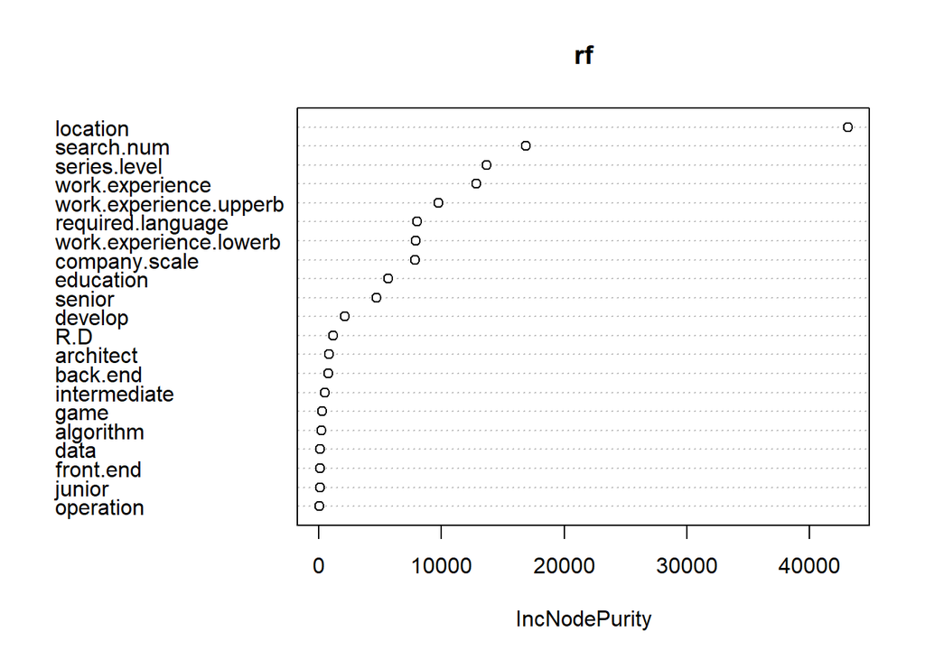

```r
varImpPlot(rf)
```

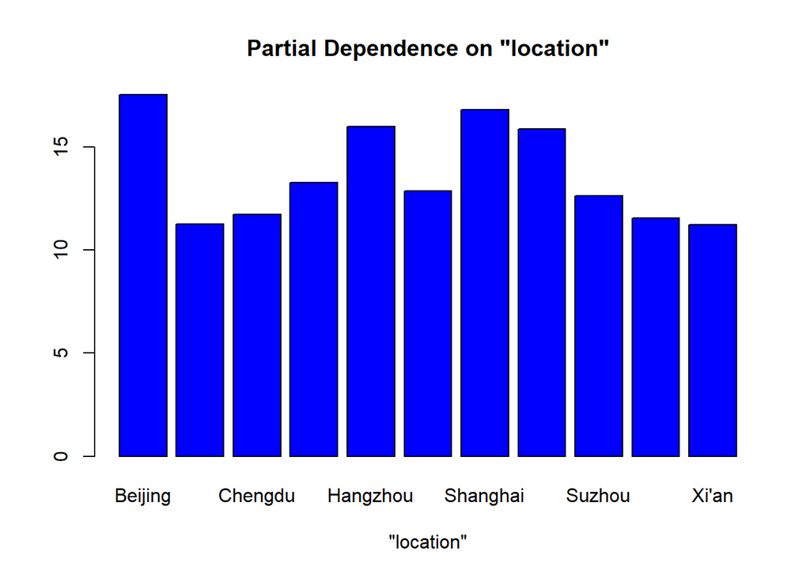

```r
partialPlot(rf, x.train, x.var="location")
```

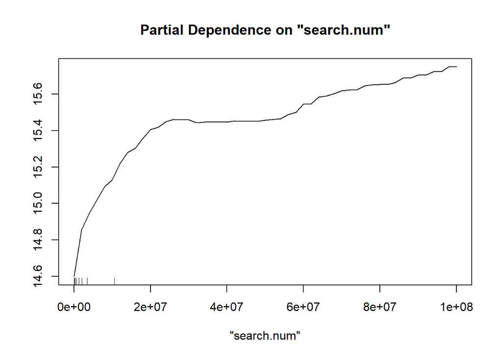

```r
partialPlot(rf, x.train, x.var="search.num")
```

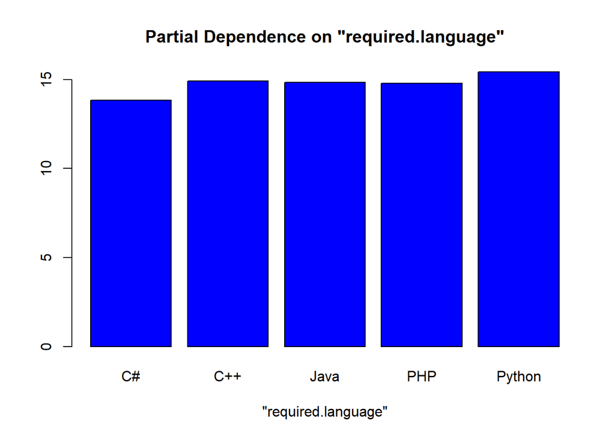

```r
partialPlot(rf, x.train, x.var="required.language")
```

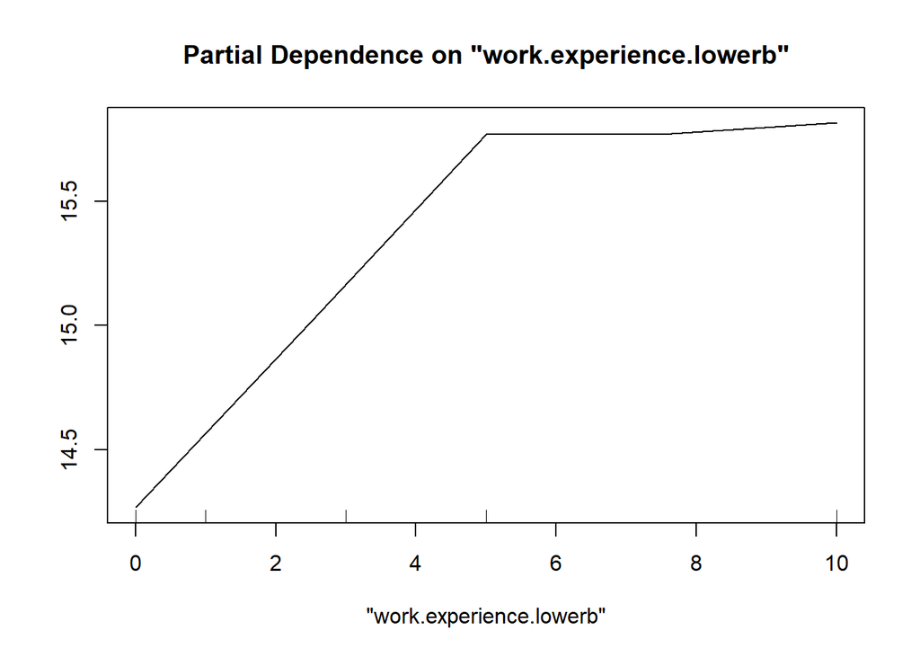

```r
partialPlot(rf, x.train, x.var="work.experience.lowerb")
```

The variable importance plot shows that location is the most important predictors in predicting programmer’s salary, because salaries differ a lot between first-tier cities and other cities. Specifically, programmers in Beijing have the highest salary while Shanghai is the 2nd highest on average. Other two cities with relatively high income are Shenzhen and Hangzhou. These four cities have high average income for programmers because of well-performed district economies and having Chinese internet leaders like Tencent, Alibaba, Baidu etc set their headquarters in these cities.

The second most important predictors in our dataset is search.num, which is the number of information that we can search on Baidu about the company. This variable can be a measure of the company’s social reputation to some extent,which means that the reputation of a company will have great influence on a programmer’s salary. Based on the partial dependence plot, company with higher reputation will pay higher for their programmers, which corresponds to common sense.

From personal perspective, important predictors include work experience and education, as in technical position, experience and knowledge is a very important factor influencing income.

One interesting finding is that within all the programming languages, python seems to be the most promising programming language. Programmers familiar with python can get slightly higher pays than other language users.